# Stat 480 - Homework #6

Zahra Khoshmanesh

2/27/2020

#### Ames housing

1. Download the RMarkdown file with these homework instructions to use as a template for your work. Make sure to replace “Your Name” in the YAML with your name.
2. The Ames based, non-profit company OAITI provides aoe open-source data sets. One of these data sets consists of information on all house sales in Ames between 2008 and 2010. The following piece of code allows you to read the dataset into your R session. How many house sales were there between 2008 and 2010? Which type of variables are we dealing with?

```r
library(dplyr)
housing <- read.csv("https://raw.githubusercontent.com/OAITI/open-datasets/master/Housing%20Data/Ames-Housing.csv")
# How many house sales were there between 2008 and 2010?
housing %>% filter(YearSold >=2008 & YearSold <=2010) %>% count()
```

```
## # A tibble: 1 x 1
##       n
##   <int>
## 1  1615
```

```r
#Which type of variables are we dealing with?
housing %>% glimpse()
```

```
## Observations: 1,615
## Variables: 10
## $ SalePrice    <int> 215000, 124500, 105000, 172000, 176500, 157000, 244000...
## $ Bedrooms     <int> 3, 2, 2, 3, 3, 4, 3, 4, 4, 4, 2, 2, 2, 2, 1, 2, 2, 2, ...
## $ Baths        <int> 1, 1, 1, 1, 1, 2, 2, 2, 2, 2, 1, 1, 1, 1, 1, 1, 1, 1, ...
## $ LotArea      <int> 31770, 13008, 11622, 14267, 11029, 10200, 11160, 12925...
## $ LivingArea   <int> 1656, 882, 896, 1329, 1414, 1434, 2110, 2117, 2112, 27...
## $ GarageArea   <int> 528, 502, 730, 312, 601, 528, 522, 550, 576, 538, 429,...
## $ Neighborhood <fct> N Ames, N Ames, N Ames, N Ames, N Ames, N Ames, N Ames...
## $ HouseStyle   <fct> 1-Story, 1-Story, 1-Story, 1-Story, 1-Story, 1-Story, ...
## $ YearBuilt    <int> 1960, 1956, 1961, 1958, 1958, 1974, 1968, 1970, 1969, ...
## $ YearSold     <int> 2010, 2009, 2010, 2010, 2008, 2009, 2010, 2008, 2008, ...
```

There is 1615 housees that sold between 2008 and 20010. The type of variables are integer and factors: integers : $ SalePrice $ Bedrooms $ Baths $ LotArea $ LivingArea $ GarageArea $ YearBuilt $ YearSold

Factors:

$ Neighborhood $ HouseStyle

```r
levels(housing$Neighborhood)
```

```
##  [1] "Blmngtn" "Blueste" "Br'Dale" "BrkSide" "ClearCr" "CollgCr" "Crawfor"
##  [8] "DakotaR" "Edwards" "Gilbert" "Greens"  "GrnHill" "IDOT&RR" "IOCondo"
## [15] "Landmrk" "MeadowV" "Mitchel" "MsCondo" "N Ames"  "NoRidge" "NPkVill"
## [22] "NridgHt" "NW Ames" "OldTown" "S&W ISU" "Sawyer"  "SawyerW" "Somerst"
## [29] "StoneBr" "Timber"  "Veenker" "WllwCr1" "WllwCr2"
```

```r
levels(housing$HouseStyle)
```

```
## [1] "1-Story" "1.5 Fin" "1.5 Unf" "2-Story" "2.5 Fin" "2.5 Unf" "S/Foyer"
## [8] "S/Level"
```

3. Do sales prices change over time? (Don’t test significances) Provide a graphic that supports your statement.

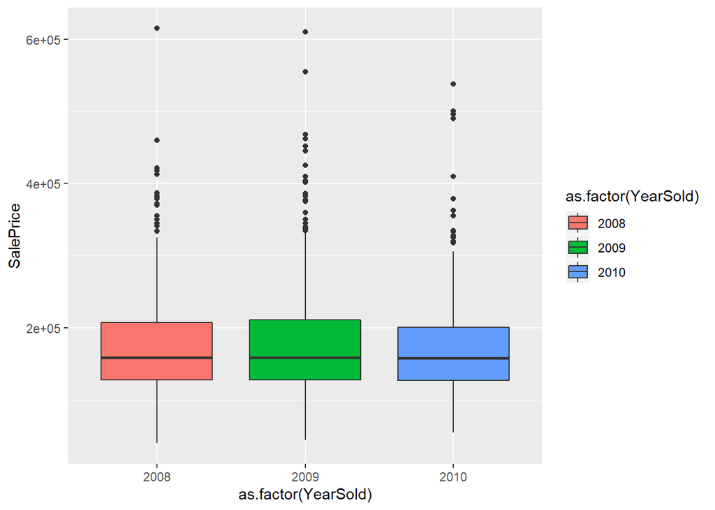

```r
ggplot(housing,aes(x=as.factor(YearSold),y=SalePrice,fill=as.factor(YearSold)))+
  geom_boxplot()
```

Based on the box plot of price in different years, the median of sale price is almost same in 2008,2009 and 2010. However, we have higher minimum sale price in 2010 and higher 75 percentile in 2009. There are many extream values in all years and the highest sale price was in 2008.

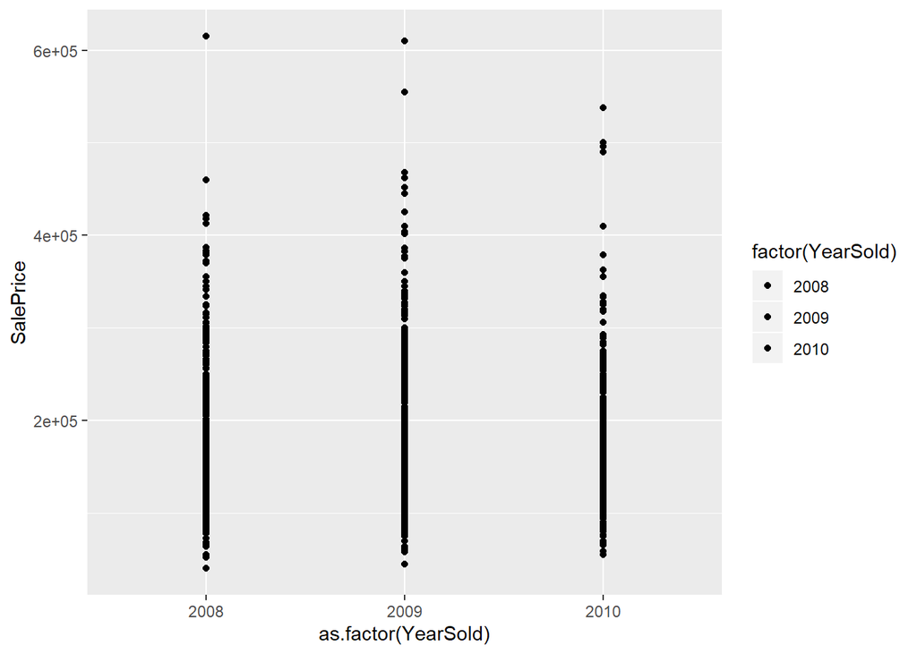

```r
ggplot(housing,aes(x=as.factor(YearSold),y=SalePrice,fill=factor(YearSold)))+
  geom_point()
```

4. What is the relationship between sales prices and the size of the house (living area)? Make a chart and describe the relationship.

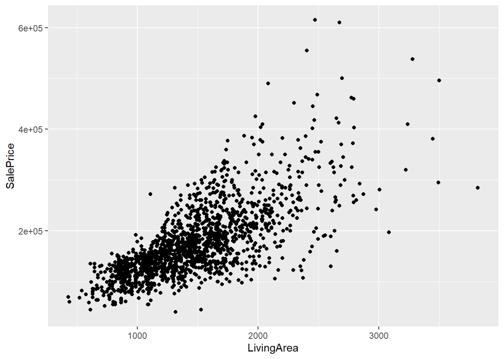

```r
ggplot(housing,aes(x=LivingArea,y=SalePrice))+
  geom_point()
```

There is a positive linear relation between size of the house and sale price. when the size of house increasing, the price also increasing.

the below chart show better linear relation between the size and price when we use log of price .

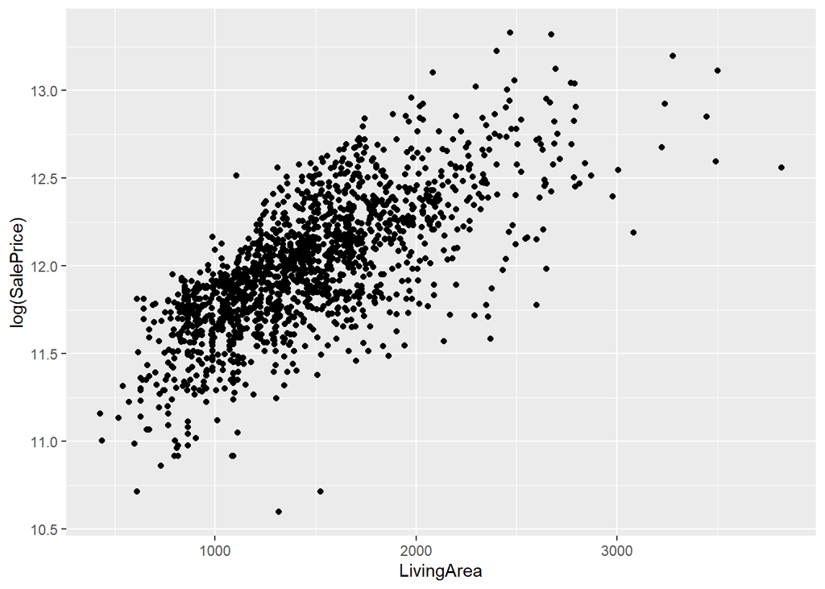

```r
ggplot(housing,aes(x=LivingArea,y=log(SalePrice)))+
  geom_point()
```

5. Use `dplyr` functions to:
- introduce a variable consisting of price per square foot,
- find the average price per square foot in each of the Ames neighborhoods,
- exclude averages that are based on fewer than 10 records,
- reorder the remaining neighborhoods according to the mean sales prices.

the calculation based on the price of lot area per square foot

```r
housing %>%
  mutate(ppf=SalePrice/LotArea) %>% #introduce new variable price per square foot
  group_by(Neighborhood) %>% #group by neighborhood
  summarise(average_per_square=mean(ppf),
            records=n(),
            mean_sale_price=mean(SalePrice)) %>%
  filter(records>=10) %>%  #filter the summary that has equal or more than 10 records
  arrange(desc(mean_sale_price)) #arrange the list based on mean sale price
```

```
## # A tibble: 27 x 4
##    Neighborhood average_per_square records mean_sale_price
##    <fct>                     <dbl>   <int>           <dbl>
##  1 NridgHt                    32.3      68         309310.
##  2 NoRidge                    25.1      38         304398.
##  3 StoneBr                    35.3      20         272820
##  4 Timber                     20.3      34         247875.
##  5 Somerst                    42.2      85         226026
##  6 ClearCr                    15.5      26         220609.
##  7 GrnHill                    27.6      22         209114.
##  8 Crawfor                    21.4      47         208341.
##  9 CollgCr                    21.3     145         199263.
## 10 NW Ames                    17.6      74         198331.
## # ... with 17 more rows
```

the calculation based on the price of living area per square foot

```r
housing %>%
  mutate(ppf=SalePrice/LivingArea) %>%
  group_by(Neighborhood) %>%
  summarise(average_per_square=mean(ppf),
            records=n(),
            mean_sale_price=mean(SalePrice)) %>%
  filter(records>=10) %>%
  arrange(desc(mean_sale_price))
```

```
## # A tibble: 27 x 4
##    Neighborhood average_per_square records mean_sale_price
##    <fct>                     <dbl>   <int>           <dbl>
##  1 NridgHt                    164.      68         309310.
##  2 NoRidge                    133.      38         304398.
##  3 StoneBr                    156.      20         272820
##  4 Timber                     148.      34         247875.
##  5 Somerst                    140.      85         226026
##  6 ClearCr                    132.      26         220609.
##  7 GrnHill                    183.      22         209114.
##  8 Crawfor                    121.      47         208341.
##  9 CollgCr                    139.     145         199263.
## 10 NW Ames                    115.      74         198331.
## # ... with 17 more rows
```

6. Draw a chart of the average sale prices by neighborhood and comment on it. Only consider neighborhoods with at least 10 sales.  
   **Bonus**: write the code for this question and the previous one in a single statement for +0.5 point extra credit.

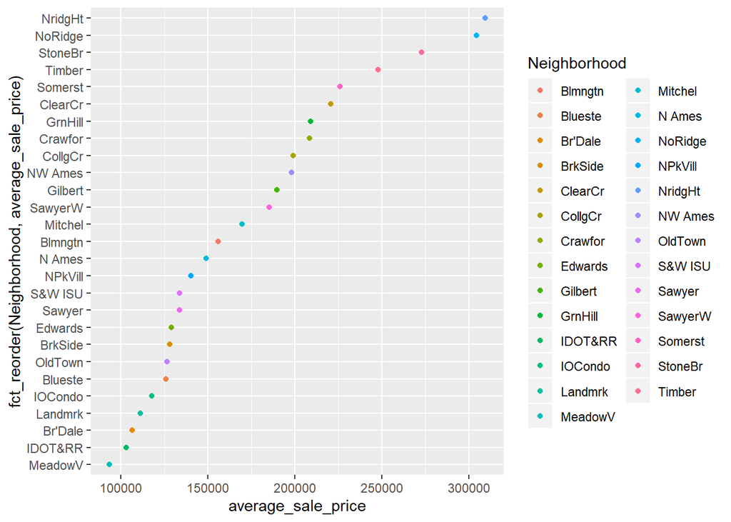

```r
housing %>%
  group_by(Neighborhood) %>% #group by neighborhood
  summarise(average_sale_price=mean(SalePrice),sale_records=n()) %>% #calculate the mean of sale price for each neighborhood
  filter(sale_records>=10) %>% #filter the mean sale price rows that has less than 10 sales
  ggplot(aes(x=average_sale_price, #draw the scatter plott of neighborhood vs. mean sale price , reorder the result
            y = fct_reorder(Neighborhood, average_sale_price),color=Neighborhood)) + geom_point()
```

As we can see the NridgHt,NoRidge,StoneBr neighborhood have the highest sale price

7. Use `dplyr` functions to:
- introduce a logical variable called ‘garage’ that is FALSE if the garage area is zero, and TRUE otherwise,
- exclude all sales of houses that do not have a garage,
- only consider 1 and 2 story houses (`HouseStyle`),
- create a new variable `YBCut` from `YearBuilt` that introduces age categories that groups the year a house was built into intervals: 1800-1850, 1850-1900, 1950-2000, 2000+ (see `?cut`).

```r
housing %>%
  mutate(garage=(GarageArea!=0)) %>%   #a logical variable called 'garage' that is FALSE if the garage area is zero, and TRUE otherwise
  filter(garage!=FALSE,HouseStyle=="1-Story" | HouseStyle=="2-Story") %>% #exclude all sales of houses that do not have a garage and only consider 1 and 2 story houses (`HouseStyle`)
  mutate(YBcut=cut(YearBuilt,c(1800,1850,1900,1950,2000,2010), #create a new variable `YBCut` from `YearBuilt`
                   labels=c("1800-1850","1850-1900","1900-1950","1950-2000","2000+"))) %>%  head()
```

```
##   SalePrice Bedrooms Baths LotArea LivingArea GarageArea Neighborhood
## 1    215000        3     1   31770       1656        528       N Ames
## 2    124500        2     1   13008        882        502       N Ames
## 3    105000        2     1   11622        896        730       N Ames
## 4    172000        3     1   14267       1329        312       N Ames
## 5    176500        3     1   11029       1414        601       N Ames
## 6    157000        4     2   10200       1434        528       N Ames
##   HouseStyle YearBuilt YearSold garage     YBcut
## 1    1-Story      1960     2010   TRUE 1950-2000
## 2    1-Story      1956     2009   TRUE 1950-2000
## 3    1-Story      1961     2010   TRUE 1950-2000
## 4    1-Story      1958     2010   TRUE 1950-2000
## 5    1-Story      1958     2008   TRUE 1950-2000
## 6    1-Story      1974     2009   TRUE 1950-2000
```

8. Draw a chart of the previous data set. Draw side-by-side boxplots of the garage area by `YBCut`. Facet by the style of house. Describe and summarise the chart.  
   **Bonus**: write the code for this question and the previous one in a single statement for +0.5 point extra credit.

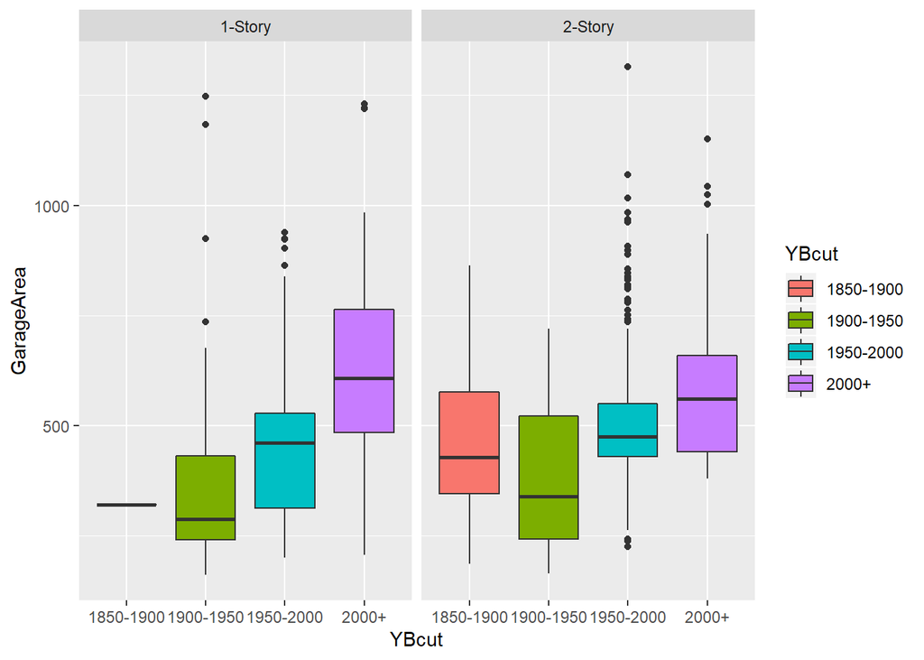

```r
housing %>%
  mutate(garage=(GarageArea!=0)) %>%
  filter(garage!=FALSE,HouseStyle=="1-Story" | HouseStyle=="2-Story") %>%
  mutate(YBcut=cut(YearBuilt,c(1800,1850,1900,1950,2000,2010),
                   labels=c("1800-1850","1850-1900","1900-1950","1950-2000","2000+"))) %>%  ggplot(aes(x=YBcut,y=GarageArea,fill=YBcut))+facet_wrap(~HouseStyle)+geom_boxplot()
```

1850-1900 : As we can see, in 1850 to 1900 the 2-story house has higher garage area compared to 1-story house. 1-story house seems has the fixed garage size in 1850 to 1900. 1900-1950 : between 1900 to 1950 1-story houses has lower median garage area size compared to 1850-1900. the same trend in 2 story house in this year range: the median of garage area size decreased compare to 1850-1900 1950-2000: the median garage size in both 1 story and 2 story increased compared to 1900-1950. we have many extream value of garage size in 2 story house. 2-story type houses has higher median garage area compared to 1-story house 2000+ : the median of garage area size in 2-story is lower than the median size of garage area of 1-story after 2000 year. seems the trend in recent year is that 1-story has higher size of garage area